# `voice` vignette

version 0.4.31

Filipe J. Zabala

2025-05-06

## 0. Basic installation

```r
devtools::install_github('filipezabala/voice')
```

More details at https://github.com/filipezabala/voice.

## 1. Extract features

### 1.1 Load packages and audio files

```r
# packs
library(voice)
library(tidyverse)

# get path to audio file
wavDir <- list.files(system.file('extdata', package = 'wrassp'),
                     pattern = glob2rx('*.wav'), full.names = TRUE)
```

### 1.2 Extract features

```r
# minimal usage
M <- voice::extract_features(wavDir)
glimpse(M)
```

```
#> Rows: 1,196
#> Columns: 13
#> $ section_seq      <int> 1, 2, 3, 4, 5, 6, 7, 8, 9, 10, 11, 12, 13, 14, 15, 16…
#> $ section_seq_file <int> 1, 2, 3, 4, 5, 6, 7, 8, 9, 10, 11, 12, 13, 14, 15, 16…
#> $ wav_path         <chr> "/Library/Frameworks/R.framework/Versions/4.4-arm64/R…
#> $ f0               <dbl> NA, NA, NA, NA, NA, NA, NA, 115.8593, 108.9439, 107.4…
#> $ f1               <int> NA, NA, NA, NA, 185, 260, 254, 277, 261, 231, 177, 19…
#> $ f2               <int> 1854, 1886, 1749, 1888, 1962, 1973, 2026, 2037, 2130,…
#> $ f3               <int> NA, 2893, 2676, 2659, 2639, 2676, 2993, 2932, 3016, 2…
#> $ f4               <int> 3113, 3708, 3509, 3658, 3248, 3239, 3830, 3479, 3561,…
#> $ f5               <int> 4191, 4678, 4502, 4331, 3653, 3836, 4602, 4585, 4720,…
#> $ f6               <int> 5226, 5659, 5035, 5177, 5208, 5146, 5233, 5390, 5366,…
#> $ f7               <int> 6077, 6725, 6526, 6518, 6493, 6567, 6603, 6532, 6510,…
#> $ f8               <int> 6675, NA, NA, NA, 7681, 7751, 7803, NA, 7835, 7614, 7…
#> $ gain             <dbl> 21.63347, 22.76034, 28.52825, 29.67069, 36.25124, 43.…
```

## 2. Tag

```r
# creating Extended synthetic data
E <- dplyr::tibble(subject_id = c(1,1,1,2,2,2,3,3,3), wav_path = wavDir)
E
```

```
#> # A tibble: 9 × 2
#>   subject_id wav_path
#>        <dbl> <chr>
#> 1          1 /Library/Frameworks/R.framework/Versions/4.4-arm64/Resources/libra…
#> 2          1 /Library/Frameworks/R.framework/Versions/4.4-arm64/Resources/libra…
#> 3          1 /Library/Frameworks/R.framework/Versions/4.4-arm64/Resources/libra…
#> 4          2 /Library/Frameworks/R.framework/Versions/4.4-arm64/Resources/libra…
#> 5          2 /Library/Frameworks/R.framework/Versions/4.4-arm64/Resources/libra…
#> 6          2 /Library/Frameworks/R.framework/Versions/4.4-arm64/Resources/libra…
#> 7          3 /Library/Frameworks/R.framework/Versions/4.4-arm64/Resources/libra…
#> 8          3 /Library/Frameworks/R.framework/Versions/4.4-arm64/Resources/libra…
#> 9          3 /Library/Frameworks/R.framework/Versions/4.4-arm64/Resources/libra…
```

```r
# minimal usage
voice::tag(E)
```

```
#> # A tibble: 9 × 7
#>   wav_path   f0_tag_mean f0_tag_sd f0_tag_vc f0_tag_median f0_tag_iqr f0_tag_mad
#>   <chr>            <dbl>     <dbl>     <dbl>         <dbl>      <dbl>      <dbl>
#> 1 /Library/…        85.4      17.6     0.206          76.1       29.4       7.53
#> 2 /Library/…        85.4      15.6     0.183          80.1       27.8      14.4
#> 3 /Library/…        84.6      13.0     0.154          78.8       23.9      14.0
#> 4 /Library/…        84.8      14.5     0.171          79.1       28.1      11.9
#> 5 /Library/…        86.0      14.7     0.170          78.7       30.0      11.0
#> 6 /Library/…        82.9      15.6     0.188          74.8       23.8       4.78
#> 7 /Library/…        78.2      16.2     0.207          73.5       13.4       6.82
#> 8 /Library/…        84.5      14.5     0.172          78.1       17.8       8.95
#> 9 /Library/…        81.0      12.2     0.151          75.9       23.1       9.14
```

```r
# canonical data
voice::tag(E, groupBy = 'subject_id')
```

```
#> # A tibble: 3 × 7
#>   subject_id f0_tag_mean f0_tag_sd f0_tag_vc f0_tag_median f0_tag_iqr f0_tag_mad
#>        <dbl>       <dbl>     <dbl>     <dbl>         <dbl>      <dbl>      <dbl>
#> 1          1        85.1      15.3     0.180          78.3       26.8      11.9
#> 2          2        84.6      14.9     0.176          76.4       28.3       7.97
#> 3          3        81.0      14.6     0.180          75.6       21.6       8.68
```

## 3. Voice2Sheet (experimental)

### 3.1 Get audio

```r
url0 <- 'https://github.com/filipezabala/voiceAudios/raw/refs/heads/main/mp3/doremi.mp3'
download.file(url0, paste0(tempdir(), '/doremi.mp3'), mode = 'wb')
embedr::embed_audio(url0)
```

[interactive chart not shown]

### 3.2 Convert mp3 to wav mono

```r
cmd <- paste0('cd ', tempdir(), ';',
' for i in *.[Mm][Pp]3; do ffmpeg -i "$i" -ac 1 "./${i%.*}.wav"; done')
system(cmd)
```

### 3.3 Media data

```r
M <- voice::extract_features(tempdir())
summary(M)
```

```
#>   section_seq    section_seq_file   wav_path               f0
#>  Min.   :  1.0   Min.   :  1.0    Length:591         Min.   :121.3
#>  1st Qu.:148.5   1st Qu.:148.5    Class :character   1st Qu.:147.8
#>  Median :296.0   Median :296.0    Mode  :character   Median :204.8
#>  Mean   :296.0   Mean   :296.0                       Mean   :208.7
#>  3rd Qu.:443.5   3rd Qu.:443.5                       3rd Qu.:259.6
#>  Max.   :591.0   Max.   :591.0                       Max.   :339.1
#>                                                      NA's   :111
#>        f1               f2             f3             f4             f5
#>  Min.   : 175.0   Min.   : 662   Min.   :1802   Min.   :2775   Min.   :3857
#>  1st Qu.: 397.0   1st Qu.:1061   1st Qu.:2510   1st Qu.:3350   1st Qu.:4296
#>  Median : 550.0   Median :1266   Median :2630   Median :3612   Median :4452
#>  Mean   : 539.1   Mean   :1347   Mean   :2626   Mean   :3563   Mean   :4458
#>  3rd Qu.: 658.0   3rd Qu.:1609   3rd Qu.:2717   3rd Qu.:3764   3rd Qu.:4572
#>  Max.   :1421.0   Max.   :3230   Max.   :3940   Max.   :4603   Max.   :5425
#>  NA's   :30       NA's   :19     NA's   :17     NA's   :15     NA's   :20
#>        f6             f7             f8            gain
#>  Min.   :4501   Min.   :5173   Min.   :6632   Min.   :10.89
#>  1st Qu.:5164   1st Qu.:6381   1st Qu.:7287   1st Qu.:19.34
#>  Median :5416   Median :6504   Median :7458   Median :21.39
#>  Mean   :5394   Mean   :6496   Mean   :7467   Mean   :21.48
#>  3rd Qu.:5555   3rd Qu.:6622   3rd Qu.:7628   3rd Qu.:23.24
#>  Max.   :6357   Max.   :7618   Max.   :8255   Max.   :34.34
#>  NA's   :15     NA's   :9      NA's   :51
```

### 3.4 Plot

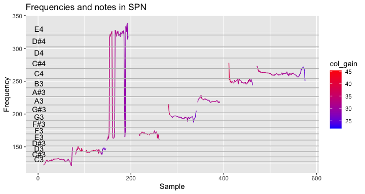

```r
voice::piano_plot(M, 0) # f0
```

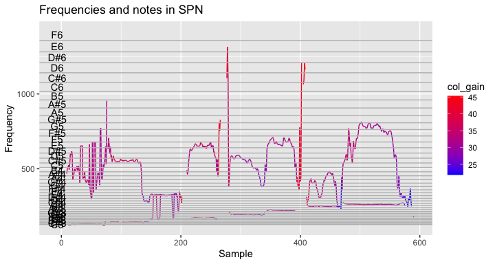

```r
voice::piano_plot(M, 0:1) # f0 + f1
```

### 3.5 Assign notes

```r
(f0_spn <- voice::assign_notes(M, fmt = 0, min_points = 22, min_percentile = .85)) # f0
```

```
#> [1] C3 D3 E4 E3 G3 A3 B3 C4
#> 108 Levels: C0 C#0 D0 D#0 E0 F0 F#0 G0 G#0 A0 A#0 B0 C1 C#1 D1 D#1 E1 F1 ... B8
```

```r
(f1_spn <- voice::assign_notes(M, fmt = 1, min_points = 22, min_percentile = .85)) # f1
```

```
#> [1] B4  C#5 E4  D5  D5  F5  F4  D#5
#> 108 Levels: C0 C#0 D0 D#0 E0 F0 F#0 G0 G#0 A0 A#0 B0 C1 C#1 D1 D#1 E1 F1 ... B8
```

### 3.6 Sheet music

Must have [MuseScore](https://musescore.org/en) and [gm](https://flujoo.github.io/gm/articles/gm.html).

#### 3.6.1 Notes sequence of f0

```r
library(gm)
line_0 <- gm::Line(as.character(f0_spn))
m0 <- gm::Music() +
  gm::Meter(4, 4) +
  line_0
gm::show(m0, to = c('score', 'audio'))
```

[figure not shown]

[interactive chart not shown]

#### 3.6.2 Notes sequences of f0 and f1

```r
line_0 <- gm::Line(as.character(f0_spn))
line_1 <- gm::Line(as.character(f1_spn))
m1 <- gm::Music() +
  gm::Meter(4, 4) +
  line_0 + line_1
gm::show(m1, to = c('score', 'audio'))
```

[figure not shown]

[interactive chart not shown]

## 4. Advanced installation

Python-based functions `diarize` and `extract_features` (when the latter is inferring `f0_praat` and `fmt_praat` features) require a configured Python environment.

### 4.1 Ubuntu

The following steps are used to fully configure `voice` on [Ubuntu 24.04 LTS (Noble Numbat)](https://ubuntu.com/blog/tag/ubuntu-24-04-lts). Reports of inconsistencies are welcome.

#### 4.1.1. [Curl](https://curl.se/)

Command line tool and library for transferring data with URLs.

```bash
# installing dependencies
sudo apt-get update
sudo apt-get install -y libssl-dev autoconf libtool make
# installing curl
sudo apt install curl
# verify installation
curl --version
```

#### 4.1.2. [ffmpeg](https://ffmpeg.org/)

ffmpeg is a cross-platform solution to record, convert and stream audio and video.

```bash
sudo apt-get update
sudo apt-get install ffmpeg
```

#### 4.1.3. Audio drivers and extra packages

```bash
sudo apt-get update
sudo apt-get install portaudio19-dev libasound2-dev libfontconfig1-dev libmagick++-dev libxml2-dev libharfbuzz-dev libfribidi-dev libgdal-dev cmake cmake-doc ninja-build
```

#### 4.1.4. [MuseScore](https://musescore.org/)

MuseScore is an open source notation software.

```bash
sudo add-apt-repository ppa:mscore-ubuntu/mscore-stable
sudo apt-get update
sudo apt-get install musescore
```

#### 4.1.5. [R](https://www.r-project.org)

R is a free software environment for statistical computing and graphics. To find out your Ubuntu distribution use `lsb_release -a` at terminal.

```bash
sudo sh -c 'echo "deb https://cloud.r-project.org/bin/linux/ubuntu focal-cran40/" >> /etc/apt/sources.list.d/cran.list'
sudo apt-key adv --keyserver keyserver.ubuntu.com --recv-keys E084DAB9
sudo apt-key adv --keyserver keyserver.ubuntu.com --recv-keys 51716619E084DAB9
gpg -a --export E084DAB9 | sudo apt-key add -

sudo add-apt-repository ppa:c2d4u.team/c2d4u4.0+

sudo apt-get update && sudo apt-get upgrade
sudo apt-get install r-base r-base-dev
```

#### 4.1.6. [RStudio](https://posit.co/download/rstudio-desktop/)

RStudio is an Integrated Development Environment (IDE) for R. Check for updates [here](https://posit.co/download/rstudio-desktop/).

```bash
sudo apt-get update
sudo apt-get install gdebi-core
wget https://download1.rstudio.org/electron/jammy/amd64/rstudio-2025.05.0-496-amd64.deb
sudo gdebi rstudio-2025.05.0-496-amd64.deb
```

#### 4.1.9. R packages

“Packages are the fundamental units of reproducible R code.” [Hadley Wickham and Jennifer Bryan](https://r-pkgs.org/). The installation may take several minutes. At terminal run:

```bash
sudo R
```

Running R as super user paste the following, row by row:

```r
packs <- c('audio''reticulate','R.utils','seewave','tidyverse','tuneR','wrassp')
install.packages(packs, dep = TRUE)
update.packages(ask = FALSE)
devtools::install_github('egenn/music')
devtools::install_github('flujoo/gm')
```

To configure the `gm` package.

```r
usethis::edit_r_environ()
```

Add the line `MUSESCORE_PATH=/usr/bin/mscore` to `/root/.Renviron` file. To exit use `:wq` at VI. Save and restart the R/RStudio session.

#### 4.1.10. [Miniconda](https://docs.conda.io/en/latest/miniconda.html)

Miniconda is a free minimal installer for [conda](https://docs.conda.io/), an open source package, dependency and environment management system for any language—Python, R, Ruby, Lua, Scala, Java, JavaScript, C/ C++, FORTRAN and more, that runs on Windows, macOS and Linux.  
Follow the instructions at https://docs.conda.io/en/latest/miniconda.html.

At terminal:

```bash
cd ~/Downloads/
wget -r -np -k https://repo.anaconda.com/miniconda/Miniconda3-latest-Linux-x86_64.sh
cd repo.anaconda.com/miniconda/
bash Miniconda3-latest-Linux-x86_64.sh
```

Do you accept the license terms? [yes|no] `yes`.

Miniconda3 will now be installed into this location: /home/user/miniconda3 [ENTER]

Do you wish the installer to initialize Miniconda3 by running conda init? `yes`. Close and reopen terminal.

```bash
conda update -n base -c defaults conda
```

The following packages will be INSTALLED/REMOVED/UPDATED/DOWNGRADED:… Proceed ([y]/n)? `y`

```bash
conda create -n pyvoice python=3.12
```

The following (NEW) packages will be downloaded/INSTALLED:… Proceed ([y]/n)? `y`

```bash
conda activate pyvoice
pip install -r https://raw.githubusercontent.com/filipezabala/voice/master/requirements.txt
```

### 4.2 MacOS

The following steps are used to fully configure `voice` on [MacOS Sonoma](https://www.apple.com/macos/sonoma/). Reports of inconsistencies are welcome.

#### 4.2.1. [Homebrew](https://brew.sh/)

Install Homebrew, ‘The Missing Package Manager for macOS (or Linux)’ and remember to `brew doctor` eventually. At terminal (`command + space 'terminal'`) run:

```bash
/bin/bash -c "$(curl -fsSL https://raw.githubusercontent.com/Homebrew/install/HEAD/install.sh)"
```

#### 4.2.2. [wget](https://www.gnu.org/software/wget/)

GNU Wget is a free software package for retrieving files using HTTP, HTTPS, FTP and FTPS, the most widely used Internet protocols. It is a non-interactive commandline tool, so it may easily be called from scripts, cron jobs, terminals without X-Windows support, etc.

```bash
brew install wget
```

#### 4.2.3. [Python](https://www.python.org/)

```bash
brew install python@3.12
python3 --version
pip3 --version
```

#### 4.2.4. [ffmpeg](https://ffmpeg.org/)

ffmpeg is a cross-platform solution to record, convert and stream audio and video. The installation may take several minutes.

```bash
brew install ffmpeg
```

#### 4.2.5. [XQuartz](https://www.xquartz.org/)

The XQuartz project is an open-source effort to develop a version of the [X.Org X Window System](https://www.x.org/wiki/) that runs on macOS.

- Download and run https://github.com/XQuartz/XQuartz/releases/download/XQuartz-2.8.5/XQuartz-2.8.5.pkg
- Will take around 320 MB of disk space
- Send XQuartz-2.8.5.dmg to Trash

#### 4.2.6. [MacPorts](https://guide.macports.org/chunked/installing.macports.html)

Follow the instructions from https://guide.macports.org/chunked/installing.macports.html.

#### 4.2.7. [tcllib](https://ports.macports.org/port/tcllib/)

```bash
sudo port selfupdate && sudo port upgrade tcllib
sudo port install tcllib
```

#### 4.2.8. [MuseScore](https://musescore.org/)

MuseScore is an open source notation software.

- Download and run https://musescore.org/en/download/musescore.dmg
- Drag MuseScore 4 to Applications folder
- Will take around 320 MB of disk space
- Unmount MuseScore-4.2.1 virtual disk and send MuseScore-4.2.1.240230937.dmg to Trash

#### 4.2.9. [R](https://www.r-project.org)

R is a free software environment for statistical computing and graphics.

- Download and run the pkg file according to you architecture from https://cloud.r-project.org/bin/macosx/
- Will take around 180 MB of disk space

#### 4.2.10. [RStudio](https://posit.co/download/rstudio-desktop/)

RStudio is an Integrated Development Environment (IDE) for R.

- Download and run https://download1.rstudio.org/electron/macos/RStudio-2025.05.0-496.dmg
- Drag RStudio to Applications folder
- Will take around 770 MB of disk space
- Unmount RStudio virtual disk and send RStudio-2025.05.0-496.dmg to Trash
- Type `command + space 'rstudio'`
- Tools > Global Options… > Appearance > Merbivore (Restart required)

#### 4.2.11. R packages

“Packages are the fundamental units of reproducible R code.” [Hadley Wickham and Jennifer Bryan](https://r-pkgs.org/). Type `command + space 'terminal'`

```bash
sudo R
```

Running R as super user paste the following, one line at a time.

```r
packs <- c('audio''reticulate','R.utils','seewave','tidyverse','tuneR','wrassp')
install.packages(packs, dep = TRUE)
update.packages(ask = FALSE)
devtools::install_github('egenn/music')
devtools::install_github('flujoo/gm')
```

#### 4.2.12. [Miniconda](https://docs.conda.io/en/latest/miniconda.html)

Miniconda is a free minimal installer for [conda](https://docs.conda.io/), an open source package, dependency and environment management system for any language—Python, R, Ruby, Lua, Scala, Java, JavaScript, C/ C++, FORTRAN and more, that runs on Windows, macOS and Linux.

For 64-bit version use

```bash
cd ~/Downloads
wget -r -np -k https://repo.anaconda.com/miniconda/Miniconda3-latest-MacOSX-x86_64.sh
cd repo.anaconda.com/miniconda/
bash Miniconda3-latest-MacOSX-x86_64.sh
```

For M1 version use

```bash
cd ~/Downloads
wget -r -np -k https://repo.anaconda.com/miniconda/Miniconda3-latest-MacOSX-arm64.sh
cd repo.anaconda.com/miniconda/
bash Miniconda3-latest-MacOSX-arm64.sh
```

In order to continue the installation process, please review the license agreement. Please, press ENTER to continue `ENTER`.

You can undo this by running `conda init --reverse $SHELL`? `yes`

Close and reopen terminal.

```bash
export PATH="~/miniconda3/bin:$PATH"
conda update -n base -c defaults conda
```

The following packages will be INSTALLED/REMOVED/UPDATED/DOWNGRADED:… Proceed ([y]/n)? `y`

```bash
conda create -n pyvoice python=3.12
```

The following (NEW) packages will be downloaded/INSTALLED:… Proceed ([y]/n)? `y`

Close and reopen terminal.

```bash
conda activate pyvoice
pip install -r https://raw.githubusercontent.com/filipezabala/voice/master/requirements.txt
```